# Filtering & Trimming Amplicon Sequences

Kailyn Hanke

2025-03-12

# Goals of this file

Output that we will create in this file:

1. Quality plots to asses pre- and post-quality trimming.
2. Written files that include the filtered and trimmed data. (Note that this will be written during the `filterAndTrim()` function.)

# Setting up the environment

### Set the seed

```r
# Any number can be chosen
set.seed(111111)

# Let's make a parameter to set the number of threads
n_threads = 20
```

###Timing of Script

```r
# What time did we start running this script?

start_time <- Sys.time()
start_time
```

```
## [1] "2025-03-12 21:13:33 EDT"
```

# Load Libraries

```r
# Efficient package loading with pacman
pacman::p_load(tidyverse, dada2, phyloseq, patchwork, DT, devtools, install = FALSE)
```

# Reading Raw Sequencing Files

```r
# Set the raw fastq path to the raw sequencing files
# Path to the fastq files
raw_fastqs_path <- "data/01_DADA2/01_raw_gzipped_fastqs"
raw_fastqs_path
```

```
## [1] "data/01_DADA2/01_raw_gzipped_fastqs"
```

```r
# What files are in this path? Intuition Check
head(list.files(raw_fastqs_path))
```

```
## [1] "ERR3141386_1.fastq.gz" "ERR3141386_2.fastq.gz" "ERR3141387_1.fastq.gz"
## [4] "ERR3141387_2.fastq.gz" "ERR3141388_1.fastq.gz" "ERR3141388_2.fastq.gz"
```

```r
# How many files are there?
length(list.files(raw_fastqs_path))
```

```
## [1] 416
```

```r
# Create vector of forward reads
forward_reads <- list.files(raw_fastqs_path, pattern = "_1.fastq.gz", full.names = TRUE)

# Intuition Checks
head(forward_reads)
```

```
## [1] "data/01_DADA2/01_raw_gzipped_fastqs/ERR3141386_1.fastq.gz"
## [2] "data/01_DADA2/01_raw_gzipped_fastqs/ERR3141387_1.fastq.gz"
## [3] "data/01_DADA2/01_raw_gzipped_fastqs/ERR3141388_1.fastq.gz"
## [4] "data/01_DADA2/01_raw_gzipped_fastqs/ERR3141389_1.fastq.gz"
## [5] "data/01_DADA2/01_raw_gzipped_fastqs/ERR3141390_1.fastq.gz"
## [6] "data/01_DADA2/01_raw_gzipped_fastqs/ERR3141391_1.fastq.gz"
```

```r
# Intuition check #2: We should have fewer reads in the forward vector than in total
stopifnot(length(forward_reads) < length(list.files(raw_fastqs_path)))

# Create a vector of reverse reads
reverse_reads <- list.files(raw_fastqs_path, pattern = "_2.fastq.gz", full.names = TRUE)

# Intuition Checks
head(reverse_reads)
```

```
## [1] "data/01_DADA2/01_raw_gzipped_fastqs/ERR3141386_2.fastq.gz"
## [2] "data/01_DADA2/01_raw_gzipped_fastqs/ERR3141387_2.fastq.gz"
## [3] "data/01_DADA2/01_raw_gzipped_fastqs/ERR3141388_2.fastq.gz"
## [4] "data/01_DADA2/01_raw_gzipped_fastqs/ERR3141389_2.fastq.gz"
## [5] "data/01_DADA2/01_raw_gzipped_fastqs/ERR3141390_2.fastq.gz"
## [6] "data/01_DADA2/01_raw_gzipped_fastqs/ERR3141391_2.fastq.gz"
```

```r
# Intuition check #2: Need to have equal number of forward and reverse files
stopifnot(length(reverse_reads) == length(forward_reads))
```

# Assess Raw Read Quality

## Evaluate raw sequence quality

Let’s see the quality of the raw reads *before* we trim

## Plot 12 random samples of plots

```r
# Randomly select 12 samples from dataset to evaluate
# Selecting 12 is typically better than 2 (like we did in class for efficiency)
random_samples <- sample(1:length(reverse_reads), size = 12)
random_samples
```

```
##  [1]  13 127  48 133  22   2  55 184 111  32 157 147
```

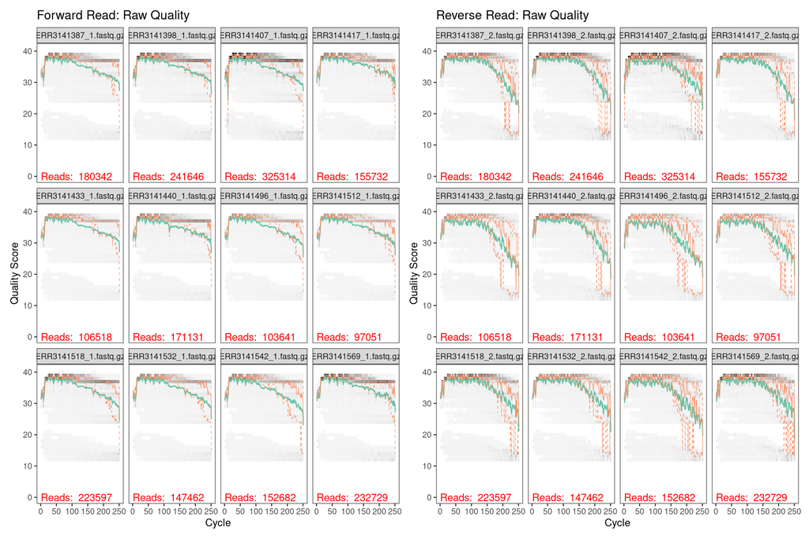

```r
# Calculate and plot quality of these two samples
forward_filteredQual_plot_12 <- plotQualityProfile(forward_reads[random_samples]) +
  labs(title = "Forward Read: Raw Quality")
reverse_filteredQual_plot_12 <- plotQualityProfile(reverse_reads[random_samples]) +
  labs(title = "Reverse Read: Raw Quality")

# Plot them together with patchwork
forward_filteredQual_plot_12 + reverse_filteredQual_plot_12
```

## Aggregated Raw Quality Plots

Next, we will plot all of the samples aggregated into one forward (left) and one reverse read (right) plot.

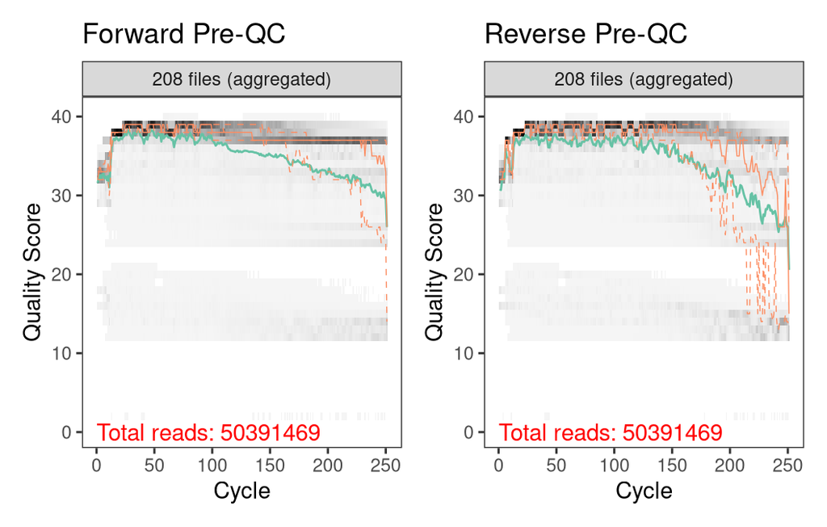

```r
# Aggregate all QC plots
# Forward reads
forward_preQC_plot <-
  plotQualityProfile(forward_reads, aggregate = TRUE) +
  labs(title = "Forward Pre-QC")

# reverse reads
reverse_preQC_plot <-
  plotQualityProfile(reverse_reads, aggregate = TRUE) +
  labs(title = "Reverse Pre-QC")

# Now, let's put the two plots together
preQC_aggregate_plot <-
  # Plot the forward and reverse together
  forward_preQC_plot + reverse_preQC_plot

# Show the plot
preQC_aggregate_plot
```

Above are plots showing the pre-QC quality scores of the raw sequencing data for the project. We can draw a few conclusions from the plots above, which were generated with 2x250 bp sequencing on an Illumina MiSeq Sequencer (amplifying the V3-V4 region of the 16S rRNA gene):

*Solutions Summary:* - Forward Reads:Truncate the reads using `truncLen = 249` - Reverse Reads:Truncate the reads using `truncLen = 240`

#### Prepare a placeholder for filtered reads

```r
# Create vector of sample names from the filenames
sample_names <- sapply(strsplit(basename(forward_reads), "_"), `[`,1)

# Intuition Check
head(sample_names)
```

```
## [1] "ERR3141386" "ERR3141387" "ERR3141388" "ERR3141389" "ERR3141390"
## [6] "ERR3141391"
```

```r
# Place filtered reads into filtered_fastqs_path
filtered_fastqs_path <- "data/01_DADA2/02_filtered_fastqs"

# Intuition Check
filtered_fastqs_path
```

```
## [1] "data/01_DADA2/02_filtered_fastqs"
```

```r
# create 2 vectors: filtered_forward_reads & filtered_reverse_reads
filtered_forward_reads <-
  file.path(filtered_fastqs_path, paste0(sample_names, "_1_filtered.fastq.gz"))

# Intuition Check #1
length(filtered_forward_reads)
```

```
## [1] 208
```

```r
#Intuition Check #2
head(filtered_forward_reads)
```

```
## [1] "data/01_DADA2/02_filtered_fastqs/ERR3141386_1_filtered.fastq.gz"
## [2] "data/01_DADA2/02_filtered_fastqs/ERR3141387_1_filtered.fastq.gz"
## [3] "data/01_DADA2/02_filtered_fastqs/ERR3141388_1_filtered.fastq.gz"
## [4] "data/01_DADA2/02_filtered_fastqs/ERR3141389_1_filtered.fastq.gz"
## [5] "data/01_DADA2/02_filtered_fastqs/ERR3141390_1_filtered.fastq.gz"
## [6] "data/01_DADA2/02_filtered_fastqs/ERR3141391_1_filtered.fastq.gz"
```

```r
# reverse reads
filtered_reverse_reads <-
  file.path(filtered_fastqs_path, paste0(sample_names, "_2_filtered.fastq.gz"))

# Intuition Check
head(filtered_reverse_reads)
```

```
## [1] "data/01_DADA2/02_filtered_fastqs/ERR3141386_2_filtered.fastq.gz"
## [2] "data/01_DADA2/02_filtered_fastqs/ERR3141387_2_filtered.fastq.gz"
## [3] "data/01_DADA2/02_filtered_fastqs/ERR3141388_2_filtered.fastq.gz"
## [4] "data/01_DADA2/02_filtered_fastqs/ERR3141389_2_filtered.fastq.gz"
## [5] "data/01_DADA2/02_filtered_fastqs/ERR3141390_2_filtered.fastq.gz"
## [6] "data/01_DADA2/02_filtered_fastqs/ERR3141391_2_filtered.fastq.gz"
```

```r
# Intuition Check #2
length(filtered_reverse_reads)
```

```
## [1] 208
```

# Filter and Trim Reads

```r
# Trimming primers:
#   Forward (341F): 17 bp (5′-CCTACGGGNGGCWGCAG)
#   Reverse (805R): 21 bp (5′-GACTACHVGGGTATCTAATCC)

# Filtering out low quality reads (threshold = quality score ~29 - 30):
#   Forward: Trim to base/cycle 249 to eliminate sudden drop in quality score
#   Reverse: Trim to base/cycle 240 to eliminate sudden drop in quality score

filtered_reads <-
  filterAndTrim(forward_reads, filtered_forward_reads,
             reverse_reads, filtered_reverse_reads,
             truncLen = c(249,240), trimLeft = c(17,21),
             maxN = 0, maxEE = c(1,1), truncQ = 2,
             rm.phix = TRUE, compress = TRUE,
             multithread = TRUE)
```

# Assess Trimmed Read Quality

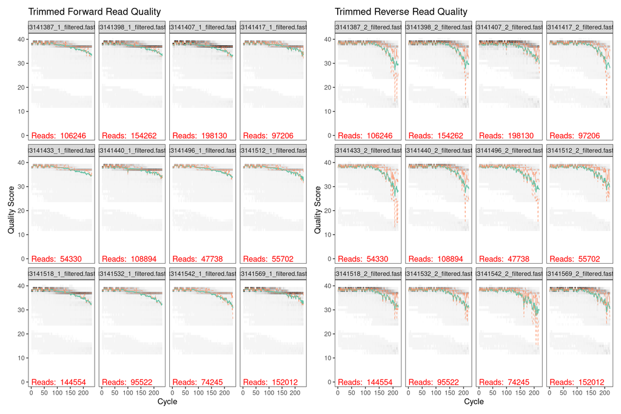

```r
# Plot the 12 random samples after QC
forward_filteredQual_plot_12 <-
  plotQualityProfile(filtered_forward_reads[random_samples]) +
  labs(title = "Trimmed Forward Read Quality")

reverse_filteredQual_plot_12 <-
  plotQualityProfile(filtered_reverse_reads[random_samples]) +
  labs(title = "Trimmed Reverse Read Quality")

# Put the two plots together
forward_filteredQual_plot_12 + reverse_filteredQual_plot_12
```

## Aggregated Trimmed Plots

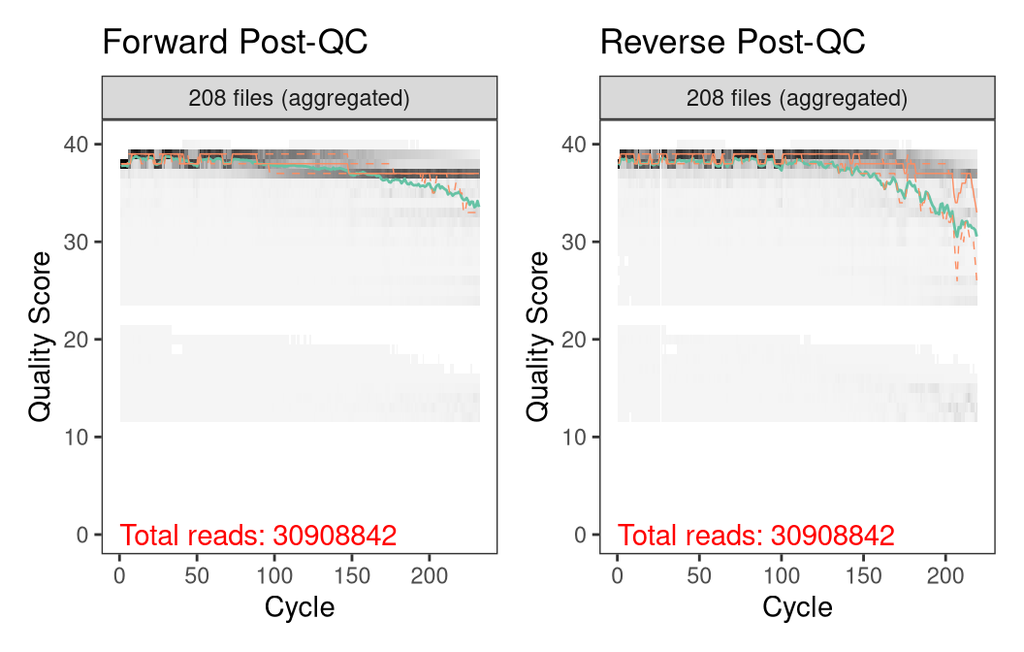

```r
# Aggregate all QC plots
# Forward reads
forward_postQC_plot <-
  plotQualityProfile(filtered_forward_reads, aggregate = TRUE) +
  labs(title = "Forward Post-QC")

# reverse reads
reverse_postQC_plot <-
  plotQualityProfile(filtered_reverse_reads, aggregate = TRUE) +
  labs(title = "Reverse Post-QC")

# Now, let's put the two plots together
postQC_aggregate_plot <-
  # Plot the forward and reverse together
  forward_postQC_plot + reverse_postQC_plot

# Show the plot
postQC_aggregate_plot
```

This post-QC quality score plot, based on 208 aggregated Illumina sequencing files, displays the forward reads (left) and reverse reads (right) after quality filtering and trimming.

- *Forward Reads Post-QC*
  - Throughout the entire read length there are high quality (Q30+) bases.
  - There is a slight decline starting around ~120-125 cycles, ending in quality scores in the mid 30’s around at the end of the read.
- *Reverse Reads Post-QC*
  - Initial bases remain stable and high-quality.
  - Mid-read quality remains strong (Q30+) until about (~175 cycles)
  - A noticeable decline in quality after ~175 cycles, but no extreme decline in quality like we saw in the pre-QC reverse reads.

**Takeaway:** Quality filtering maintained high-quality bases while removing primers and low-quality tails.

## Read Retention Post-QC

```r
# Make output into dataframe
filtered_df <- as.data.frame(filtered_reads) %>%
  mutate(percent.retained = reads.out/reads.in)

# Intuition check
# Visualize it in table format
DT::datatable(filtered_df)
```

|  | reads.in | reads.out | percent.retained |
| --- | --- | --- | --- |
| ERR3141386_1.fastq.gz | 198299 | 117162 | 0.5908350521182658 |
| ERR3141387_1.fastq.gz | 180342 | 106246 | 0.5891361967816704 |
| ERR3141388_1.fastq.gz | 420609 | 273873 | 0.6511344265101318 |
| ERR3141389_1.fastq.gz | 223724 | 148732 | 0.6648012729970857 |
| ERR3141390_1.fastq.gz | 254049 | 157811 | 0.6211833150297777 |
| ERR3141391_1.fastq.gz | 135706 | 91784 | 0.6763444505032938 |
| ERR3141392_1.fastq.gz | 195692 | 130505 | 0.6668898064305132 |
| ERR3141393_1.fastq.gz | 235673 | 153077 | 0.6495313421562928 |
| ERR3141394_1.fastq.gz | 483306 | 304465 | 0.6299632117126623 |
| ERR3141395_1.fastq.gz | 223587 | 144542 | 0.6464687124027784 |

[output cut: 198 more lines]

```r
# Let's calculate some statistics
read_stats_df <-
  filtered_df %>%
  reframe(median_reads_in = median(reads.in),
          median_reads_out = median(reads.out),
          median_percent_retained = (median(reads.out)/median(reads.in)),
          max_percent_retained = max(reads.out/reads.in),
          min_percent_retained = min(reads.out/reads.in))

# Take a look at it!
read_stats_df
```

```
##   median_reads_in median_reads_out median_percent_retained max_percent_retained
## 1        180524.5         113651.5               0.6295627              0.74676
##   min_percent_retained
## 1            0.1274155
```

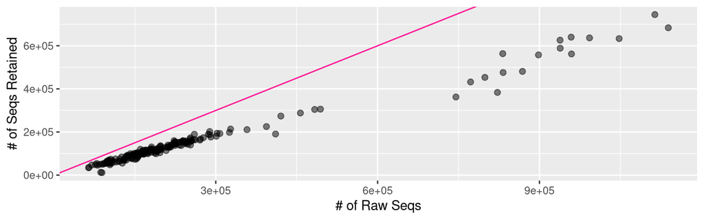

```r
# Plot it
numSeqs_QC_dotplot <-
  filtered_df %>%
  ggplot(aes(x = reads.in, y = reads.out)) +
  geom_point(alpha = 0.5, size = 2) +
  labs(x = "# of Raw Seqs",
       y = "# of Seqs Retained") +
  # Now let's add a 1:1 line for reference of keeping 100% of the reads
  geom_abline(slope=1, intercept = 0, color = "deeppink")

#View Plot
numSeqs_QC_dotplot
```

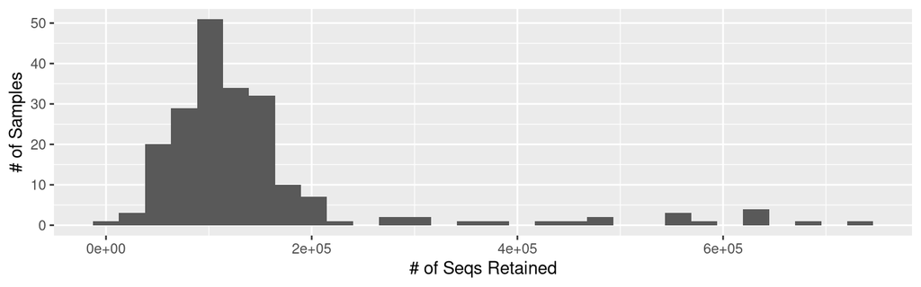

```r
# Now, let's look at the number of reads retained in a histogram
numRetained_QC_histplot <-
  filtered_df %>%
  ggplot(aes(x = reads.out)) +
  geom_histogram() +
  labs(x = "# of Seqs Retained",
       y = "# of Samples")

#View Plot
numRetained_QC_histplot
```

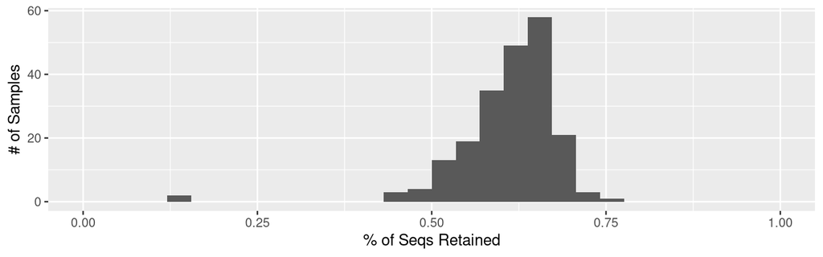

```r
# Create a histogram of percent reads retained in a histogram
percSeqs_QC_histplot <-
  filtered_df %>%
  ggplot(aes(x = percent.retained)) +
  geom_histogram() +
  labs(x = "% of Seqs Retained",
       y = "# of Samples") +
  # Set the scale to be between 0-1 (0-100%)
  scale_x_continuous(limits = c(0, 1))

#View histogram
percSeqs_QC_histplot
```

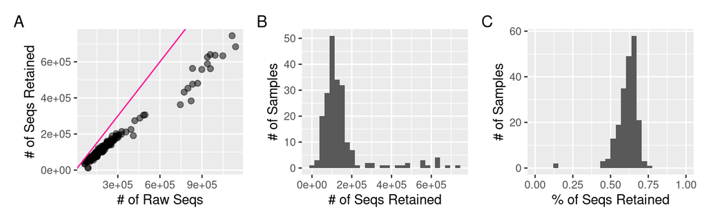

```r
# Now, let's put the plots together
numSeqs_QC_dotplot + numRetained_QC_histplot + percSeqs_QC_histplot +
  plot_annotation(tag_levels = 'A')
```

**Panel A: Scatter Plot of Raw vs. Retained Sequences:**

**Panel B: Histogram of the Number of Sequences Retained per Sample**

*Interpretation of Panel B*

- The majority of samples have between ~50,000 and 150,000 retained sequences, which suggests good filtering efficiency; overall, most samples retained a high number of sequences, suggesting filtering was effective without excessive loss.
- Most of the samples had a fairly tight distribution, although 10-15 samples had a much higher # of sequences retained.

**Panel C: Histogram of Percent of Sequences Retained**

*Interpretation of Panel C*.

- Most samples retained ~45-70% of their sequences, meaning that filtering did aggressively remove data.
- **Max % Retained** is 0.74676 is not great, while **min % retained is** 0.1274155 which isn’t super great either.
- The **median % retained** was 0.6295627.

### Visualize QC differences in plot

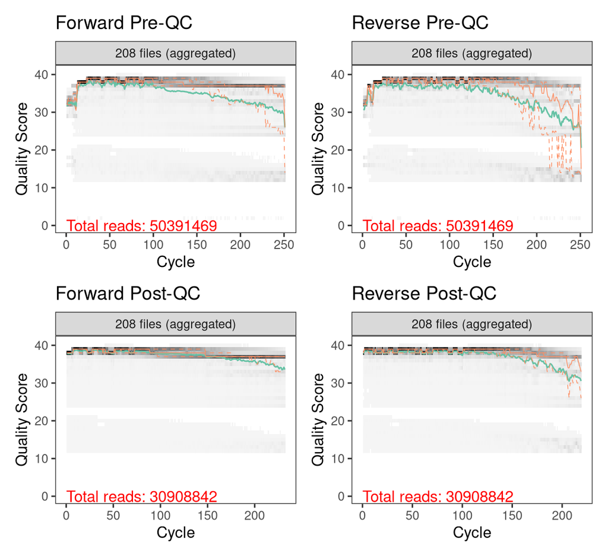

```r
# Plot the pre and post together in one plot
preQC_aggregate_plot / postQC_aggregate_plot
```

**Quality Score Improvements**

- *Forward Reads (Pre vs. Post-QC)*
  - *Beginning of read*: The forward primer (first 17 bases) was trimmed. This also effectively got rid of any lower quality bases that were present at the beginning of the reads. The majority of Phred scores are very good ~37.
  - *Middle of read*: Similar to the pre-QC forward reads, the post-QC reads have quality that remains consistently high. Most reads have Phred scores from Q37-Q40 across most cycles/bases.
  - *End of read*: Pre-QC reads had a gradual decline in quality from ~150 cycles/bases until the end of the read length, with a steeper drop in quality at ~249 cycles/bases. In the post-QC reads, there is a slight decline in Phred scores, with no super low quality tails.
- *Reverse Reads (Pre vs. Post-QC)*
  - *Beginning of read*: The reverse primer (first 21 bases) was trimmed. This also effectively got rid of the lower quality bases that were present at the beginning of the reads. The majority of Phred scores are very good ~37 (similar to forward reads).
  - *Middle of read*: Mid-read quality remains strong until ~140 bp. Where there begins to be a gradual decline in Phred scores.
  - *End of read*: Pre-QC reads had a gradual decline in quality from ~140 cycles/bases until the end of the read length, with a steeper drop in quality at the very end of the read. Note that this gradual decline is more significant in the reverse reads vs. the forward reads. The trailing end of the reverse reads still shows some degradation, but it’s significantly improved from pre-QC by trimming those last 10 bases which were lowest quality.

In summary I think I have sufficiently QC’d my sequencing data, as I have effectively removed the parts of the sequences that are low quality. Assuming I did the filterAndTrim step correctly, I do trust the quality of my data. The one thing I am worried about is if I will have sufficient overlap am able to smoothly merge in the next steps of processing.

# Check Render Time

```r
# Take the time now that we are at the end of the script
end_time <- Sys.time()
end_time
```

```
## [1] "2025-03-12 22:17:51 EDT"
```

```r
# Echo the elapsed time
elapsed_time <- round((end_time - start_time), 3)
elapsed_time
```

```
## Time difference of 1.072 hours
```